# Practical Machine Learning - HAR Prediction

Chang, Yang Yaw

Sunday, December 27, 2015

# Executive Summary

In this report, analysis is done on [HAR](http://groupware.les.inf.puc-rio.br/har) [training dataset](https://d396qusza40orc.cloudfront.net/predmachlearn/pml-training.csv) and a decision tree will be used to predict HAR [testing dataset](https://d396qusza40orc.cloudfront.net/predmachlearn/pml-testing.csv). The predictive model shall predict the manner in which they did the exercise. This is the “classe” variable in the training set. In this report, following key questions will be attended:

- How the model is built.
- How cross validation is used
- The expected out of sample error
- Justification on the choices made.

# Data Preprocessing and Feature Reduction

## Load required libraries

```r
library(caret)
library(kernlab)
library(ggplot2)
library(randomForest)
library(rpart)
library(rattle)
```

## Load and analyse testing and training data.

```r
testing<-read.csv(file="pml-testing.csv",head=TRUE,sep=",")
training<-read.csv(file="pml-training.csv",head=TRUE,sep=",")
str(testing)
str(training)
```

## Cleaning the feature by removing columns which are not meaningful (% of NA < 70% and prior knowledge)

```r
dim(training)
```

```
## [1] 19622   160
```

```r
nzv <- nearZeroVar(training, saveMetrics=TRUE)
training.temp <- training[,nzv$nzv==FALSE]
cut.off <- round(dim(training)[1]*0.3, 0)
training.temp <- training.temp[, colSums(is.na(training.temp)) < cut.off]
remove = c('X', 'user_name', 'raw_timestamp_part_1', 'raw_timestamp_part_2', 'cvtd_timestamp', 'new_window', 'num_window')
training.meaningful <- training.temp[, -which(names(training.temp) %in% remove)]
```

## Reduce dimension of data by removing highly correlated columns (corr >= 0.9)

```r
corrMatrix <- cor(na.omit(training.meaningful[sapply(training.meaningful, is.numeric)]))
dim(corrMatrix)
```

```
## [1] 52 52
```

```r
removecor = findCorrelation(corrMatrix, cutoff = .90, verbose = TRUE)
```

```
## Compare row 10  and column  1 with corr  0.992
##   Means:  0.27 vs 0.168 so flagging column 10
## Compare row 1  and column  9 with corr  0.925
##   Means:  0.25 vs 0.164 so flagging column 1
## Compare row 9  and column  4 with corr  0.928
##   Means:  0.233 vs 0.161 so flagging column 9
## Compare row 8  and column  2 with corr  0.966
##   Means:  0.245 vs 0.157 so flagging column 8
## Compare row 19  and column  18 with corr  0.918
##   Means:  0.091 vs 0.158 so flagging column 18
## Compare row 46  and column  31 with corr  0.914
##   Means:  0.101 vs 0.161 so flagging column 31
## Compare row 46  and column  33 with corr  0.933
##   Means:  0.083 vs 0.164 so flagging column 33
## All correlations <= 0.9
```

```r
training.final = training.meaningful[,-removecor]
dim(training.final)
```

```
## [1] 19622    46
```

Feature has reduced from 160 to 46 after data cleansing.

## Split the training set into training and test set

```r
index.train <- createDataPartition(training.final$classe, p=0.66, list=FALSE)
data.training <- training.final[index.train, ]
data.testing <- training.final[-index.train, ]
```

2/3 of data is used for training and 1/3 is used for validation.

# Analysis

## Decision Tree

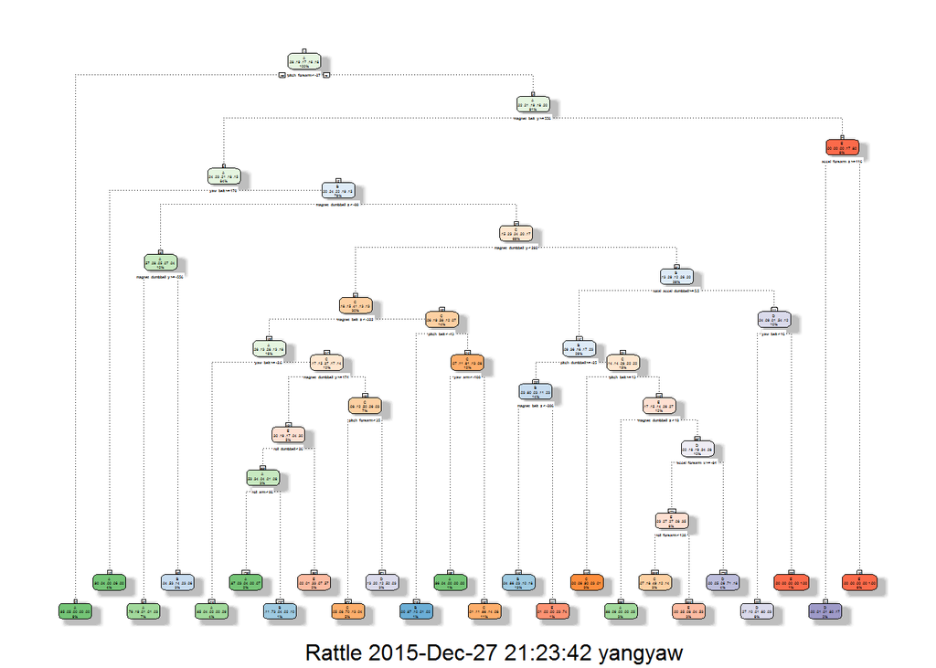

```r
set.seed(12345)
decision.tree.model <- rpart(classe ~ ., data=data.training, method="class")
fancyRpartPlot(decision.tree.model)
```

```r
decision.tree.validation <- predict(decision.tree.model, data.testing, type = "class")
decision.tree.cm <- confusionMatrix(decision.tree.validation, data.testing$classe)
decision.tree.cm
```

```
## Confusion Matrix and Statistics
##
##           Reference
## Prediction    A    B    C    D    E
##          A 1629  174   26   22  136
##          B   47  759   68  138  196
##          C   35  160  958  191  104
##          D  185  115   47  704   96
##          E    1   82   64   38  694
##
## Overall Statistics
##
##                Accuracy : 0.7114
##                  95% CI : (0.7003, 0.7222)
##     No Information Rate : 0.2845
##     P-Value [Acc > NIR] : < 2.2e-16
##
##                   Kappa : 0.6346
##  Mcnemar's Test P-Value : < 2.2e-16
##
## Statistics by Class:
##
##                      Class: A Class: B Class: C Class: D Class: E
## Sensitivity            0.8587   0.5884   0.8237   0.6441   0.5661
## Specificity            0.9250   0.9165   0.9110   0.9206   0.9660
## Pos Pred Value         0.8198   0.6283   0.6616   0.6138   0.7895
## Neg Pred Value         0.9428   0.9028   0.9607   0.9296   0.9081
## Prevalence             0.2845   0.1934   0.1744   0.1639   0.1838
## Detection Rate         0.2443   0.1138   0.1436   0.1056   0.1041
## Detection Prevalence   0.2979   0.1811   0.2171   0.1720   0.1318
## Balanced Accuracy      0.8919   0.7524   0.8674   0.7823   0.7660
```

```r
decision.tree.cm$overall['Accuracy']
```

```
## Accuracy
## 0.711351
```

Accuracy of 0.7113 is obtained thru decision tree modelling technique. To improve the accuracy, decision tree with boostrap (cross validation): Random Forest is used.

## Random Forest

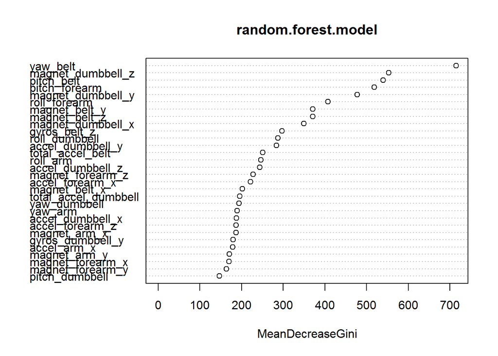

```r
set.seed(12345)
random.forest.model <- randomForest(classe ~ ., data=data.training)
varImpPlot(random.forest.model,)
```

```r
random.forest.validation <- predict(random.forest.model, data.testing, type = "class")
random.forest.cm <- confusionMatrix(random.forest.validation, data.testing$classe)
random.forest.cm$overall['Accuracy']
```

```
##  Accuracy
## 0.9938522
```

Accuracy of 0.9938 is obtained thru random forest modelling technique.

## Comparison

The use of bootstrap technique has yielded higher accuracy in prediction. Hence, random forest shall be used for this analysis.

# Conclusion

Random Forest model has OOB estimates of 0.73%.

```r
random.forest.model
```

```
##
## Call:
##  randomForest(formula = classe ~ ., data = data.training)
##                Type of random forest: classification
##                      Number of trees: 500
## No. of variables tried at each split: 6
##
##         OOB estimate of  error rate: 0.73%
## Confusion matrix:
##      A    B    C    D    E  class.error
## A 3680    2    0    0    1 0.0008145534
## B   14 2486    7    0    0 0.0083765457
## C    0   25 2231    3    0 0.0123948650
## D    0    0   32 2089    2 0.0160150730
## E    0    0    2    6 2373 0.0033599328
```

Applying prediction model on testing data

```r
final.prediction <- predict(random.forest.model, testing, type = "class")
final.prediction
```

```
##  1  2  3  4  5  6  7  8  9 10 11 12 13 14 15 16 17 18 19 20
##  B  A  B  A  A  E  D  B  A  A  B  C  B  A  E  E  A  B  B  B
## Levels: A B C D E
```

Write results into text file for submission

```r
pml_write_files = function(x){
    n = length(x)
    for(i in 1:n){
        filename = paste0("problem_id_",i,".txt")
        write.table(x[i],file=filename,quote=FALSE,row.names=FALSE,col.names=FALSE)
    }
}

pml_write_files(final.prediction)
```